# Impact of extreme weather events on human helath and estimating fatalities

Manjari singh

2024-06-30

# Synopsis

Storms and other severe weather events can cause both public health and economic problems for communities and municipalities. Many severe events can result in fatalities, injuries, and property damage, and preventing such outcomes to the extent possible is a key concern. This project involves exploring the NOAA’s storm database, which tracks characteristics of major storms and weather events in the United States, including when and where they occur, as well as estimates of any fatalities, injuries, and property damage. The basic goal of this assignment is to explore the NOAA Storm Database and answer some basic questions about severe weather events, such as: - Across the US, which types of events (as indicated in the EVTYPE variable) are most harmful with respect to population health? - Across the US, which types of events have the greatest economic consequences?

The result indicated that Tornado followed by Excessive heat, Tstm Wind and Flooding are the ones having greatest impact on population health. Moreover, Flood followed by Hurricane/typhoon, Tornado and Storm Surge are the ones having greatest impact on economic.

# Data Processing

### set directory, load data, and see data structure

```r
setwd("C:/Users/MSingh/coursera/assignment/data")
noaa_data <- read.csv("repdata_data_StormData.csv", na.strings = TRUE)
str(noaa_data)
```

```
## 'data.frame':    903870 obs. of  40 variables:
##  $ STATE__   : chr  "1" "1" "1" "1" ...
##  $ BGN_DATE  : chr  "4/18/1950 0:00" "4/18/1950 0:00" "2/20/1951 0:00" "6/8/1951 0:00" ...
##  $ BGN_TIME  : chr  "130" "145" "1600" "900" ...
##  $ TIME_ZONE : chr  "CST" "CST" "CST" "CST" ...
##  $ COUNTY    : chr  "97" "3" "57" "89" ...
##  $ COUNTYNAME: chr  "MOBILE" "BALDWIN" "FAYETTE" "MADISON" ...
##  $ STATE     : chr  "AL" "AL" "AL" "AL" ...
##  $ EVTYPE    : chr  "TORNADO" "TORNADO" "TORNADO" "TORNADO" ...
##  $ BGN_RANGE : chr  "0" "0" "0" "0" ...
##  $ BGN_AZI   : chr  "" "" "" "" ...
##  $ BGN_LOCATI: chr  "" "" "" "" ...
##  $ END_DATE  : chr  "" "" "" "" ...
##  $ END_TIME  : chr  "" "" "" "" ...
##  $ COUNTY_END: chr  "0" "0" "0" "0" ...
```

[output cut: 26 more lines]

since all columns are of character datatype, we need to tranform few columns which has o be used during data analysis ### transform datatype of required columns to numeric type

```r
library(dplyr)
noaa_data <- noaa_data %>% mutate_at(c('INJURIES', 'FATALITIES', 'PROPDMG', 'CROPDMG'), as.numeric)
str(noaa_data)
```

```
## 'data.frame':    903870 obs. of  40 variables:
##  $ STATE__   : chr  "1" "1" "1" "1" ...
##  $ BGN_DATE  : chr  "4/18/1950 0:00" "4/18/1950 0:00" "2/20/1951 0:00" "6/8/1951 0:00" ...
##  $ BGN_TIME  : chr  "130" "145" "1600" "900" ...
##  $ TIME_ZONE : chr  "CST" "CST" "CST" "CST" ...
##  $ COUNTY    : chr  "97" "3" "57" "89" ...
##  $ COUNTYNAME: chr  "MOBILE" "BALDWIN" "FAYETTE" "MADISON" ...
##  $ STATE     : chr  "AL" "AL" "AL" "AL" ...
##  $ EVTYPE    : chr  "TORNADO" "TORNADO" "TORNADO" "TORNADO" ...
##  $ BGN_RANGE : chr  "0" "0" "0" "0" ...
##  $ BGN_AZI   : chr  "" "" "" "" ...
##  $ BGN_LOCATI: chr  "" "" "" "" ...
##  $ END_DATE  : chr  "" "" "" "" ...
##  $ END_TIME  : chr  "" "" "" "" ...
##  $ COUNTY_END: chr  "0" "0" "0" "0" ...
```

[output cut: 26 more lines]

# Events which are most harmful with respect to population health

Tin order to determine which events are most harmful to population health, examine injuries and fatalities data for each event type

```r
casualties <- aggregate(cbind(noaa_data$INJURIES, noaa_data$FATALITIES) ~ noaa_data$EVTYPE, data = noaa_data, sum)
## Change column names for better presentation
colnames(casualties) <- c("EventType", "Injuries", "Fatalities")
```

Events that causes the most harmful impact to population health will be ones that have high Injuries and Fatalities values:

```r
## Add new column Injuries_Fatalities which is the sum of the other two
casualties$Injuries_Fatalities <- casualties$Injuries + casualties$Fatalities
## Sort data by Injuries_Fatalities
casualties <- casualties[with(casualties, order(-Injuries_Fatalities)),]
```

Top 10 events area:

```r
head(casualties, 10)
```

```
##             EventType Injuries Fatalities Injuries_Fatalities
## 834           TORNADO    90671       5593               96264
## 130    EXCESSIVE HEAT     6525       1903                8428
## 856         TSTM WIND     6957        504                7461
## 170             FLOOD     6789        470                7259
## 464         LIGHTNING     5230        816                6046
## 275              HEAT     2100        937                3037
## 153       FLASH FLOOD     1777        978                2755
## 427         ICE STORM     1975         89                2064
## 760 THUNDERSTORM WIND     1488        133                1621
## 972      WINTER STORM     1321        206                1527
```

# Events have the greatest economic consequences

Economic consequences are determined by total property damage values (PROPDMG, PROPDMGEXP) and total crop damage value (CROPDMG, CROPDMGEXP). PROPDMGEXP and CROPDMGEXP have values of “H”, “K”, “M”, “B” (hundred, thousand, million, billion respectively multiplier). create a function to calculate this multiplier:

```r
get_exp_multiplier <- function(m) {
    if (m %in% c('H', 'h'))
        return (100)
    else if (m %in% c('K', 'k'))
        return (1000)
    else if (m %in% c('M', 'm'))
        return (1000000)
    else if (m %in% c('B', 'b'))
        return (1000000000)
    else if (!is.na(as.numeric(m)))
        return (as.numeric(m) * 10)
    else
        return(1)
}
```

Then calculate total property and crop damage values:

```r
## Calculate total property damage
prop_dmg_mul <- sapply(noaa_data$PROPDMGEXP, FUN=get_exp_multiplier)
```

[output not shown]

[output cut: 274 more lines]

[output not shown]

```r
noaa_data$total_prop_dmg <- noaa_data$PROPDMG * prop_dmg_mul
## Get crop damage multiplier
crop_dmg_mul <- sapply(noaa_data$CROPDMGEXP, FUN=get_exp_multiplier)
```

[output not shown]

[output cut: 534 more lines]

[output not shown]

```r
noaa_data$total_crop_dmg <- noaa_data$CROPDMG * crop_dmg_mul
```

Group them by event type

```r
storm_econ_dmg <- aggregate(cbind(noaa_data$total_prop_dmg, noaa_data$total_crop_dmg) ~ noaa_data$EVTYPE, data = noaa_data, sum)
## Change column names for better presentation
colnames(storm_econ_dmg) <- c("EventType", "Property_Dmg", "Crop_Dmg")
```

Events that have the greatest economic consequences will be ones that have high property damage and crop damage values

```r
## Add new column Prop_Crop_Dmg which is the sum of the other two
storm_econ_dmg$Prop_Crop_Dmg <- storm_econ_dmg$Property_Dmg + storm_econ_dmg$Crop_Dmg
## Sort data by Prop_Crop_Dmg
storm_econ_dmg <- storm_econ_dmg[with(storm_econ_dmg, order(-Prop_Crop_Dmg)),]
```

Here are top 10 events:

```r
head(storm_econ_dmg, 10)
```

```
##             EventType Property_Dmg    Crop_Dmg Prop_Crop_Dmg
## 170             FLOOD 144657709807  5661968450  150319678257
## 411 HURRICANE/TYPHOON  69305840000  2607872800   71913712800
## 834           TORNADO  55845959553   414953110   56260912663
## 670       STORM SURGE  43323536000        5000   43323541000
## 244              HAIL  15731438777  3025954453   18757393230
## 153       FLASH FLOOD  16140817485  1421317100   17562134585
## 95            DROUGHT   1046106000 13972566000   15018672000
## 402         HURRICANE  11868319010  2741910000   14610229010
## 590       RIVER FLOOD   5118945500  5029459000   10148404500
## 427         ICE STORM   3944927810  5022113500    8967041310
```

#Results -From our analysis, Tornado is the one that has greatest impact on population health with over 96,000 injuries and fatalities, followed by Excessive heat, Tstm Wind and Flooding which caused around 8000 injuries and fatalities in each.

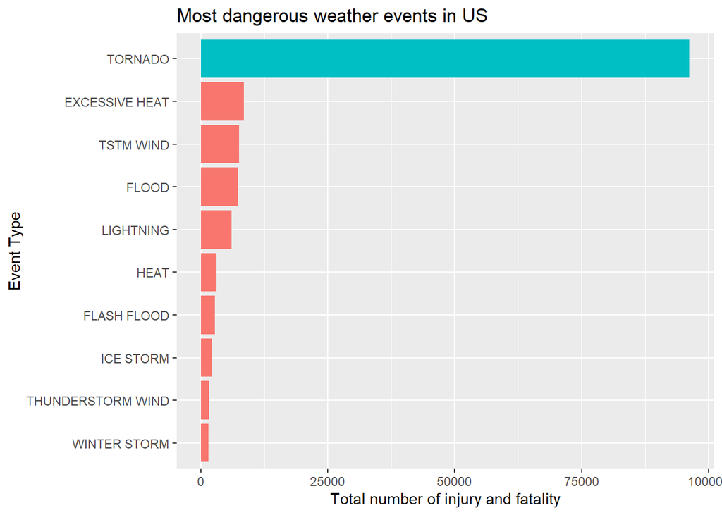

```r
library(ggplot2)
## Add colors
casualties$FillColor = "blue"
casualties[1,]$FillColor = "red"
g1 <- ggplot(data = head(casualties, 10), aes(x = reorder(EventType, Injuries_Fatalities), y = Injuries_Fatalities, fill = FillColor)) + geom_bar(stat = "identity") + coord_flip() + theme(legend.position="none")
g1 <- g1 + labs( x = "Event Type", y = "Total number of injury and fatality", title = "Most dangerous weather events in US")
g1
```

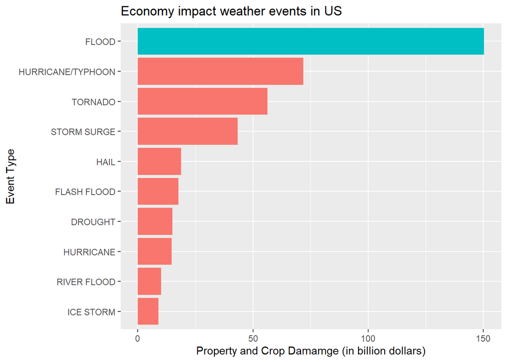

```r
library(ggplot2)
## Add colors
storm_econ_dmg$FillColor = "blue"
storm_econ_dmg[1,]$FillColor = "red"
g2 <- ggplot(data = head(storm_econ_dmg, 10), aes(x = reorder(EventType, Prop_Crop_Dmg), y = Prop_Crop_Dmg / 10^9, fill = FillColor)) + geom_bar(stat = "identity") + coord_flip() + theme(legend.position="none")
g2 <- g2 + labs( x = "Event Type", y = "Property and Crop Damamge (in billion dollars)", title = "Economy impact weather events in US")
g2
```